# Lab4

Student 1: Brian Pattison  
Student 2: Mitch Morrison  
Student 3: Kyle Kolodziej  
Student 4: Sam Yassien

```python
#imports
import pandas as pd
import numpy as np
import seaborn as sns
import matplotlib
import matplotlib.pyplot as plt
import warnings
from sklearn.metrics import accuracy_score
warnings.filterwarnings('ignore')
```

```python
df = pd.read_csv('../../acs2017_census_tract_data.csv')
df.head()
```

|  | TractId | State | County | TotalPop | Men | Women | Hispanic | White | Black | Native | ... | Walk | OtherTransp | WorkAtHome | MeanCommute | Employed | PrivateWork | PublicWork | SelfEmployed | FamilyWork | Unemployment |
| --- | --- | --- | --- | --- | --- | --- | --- | --- | --- | --- | --- | --- | --- | --- | --- | --- | --- | --- | --- | --- | --- |
| 0 | 1001020100 | Alabama | Autauga County | 1845 | 899 | 946 | 2.4 | 86.3 | 5.2 | 0.0 | ... | 0.5 | 0.0 | 2.1 | 24.5 | 881 | 74.2 | 21.2 | 4.5 | 0.0 | 4.6 |
| 1 | 1001020200 | Alabama | Autauga County | 2172 | 1167 | 1005 | 1.1 | 41.6 | 54.5 | 0.0 | ... | 0.0 | 0.5 | 0.0 | 22.2 | 852 | 75.9 | 15.0 | 9.0 | 0.0 | 3.4 |
| 2 | 1001020300 | Alabama | Autauga County | 3385 | 1533 | 1852 | 8.0 | 61.4 | 26.5 | 0.6 | ... | 1.0 | 0.8 | 1.5 | 23.1 | 1482 | 73.3 | 21.1 | 4.8 | 0.7 | 4.7 |
| 3 | 1001020400 | Alabama | Autauga County | 4267 | 2001 | 2266 | 9.6 | 80.3 | 7.1 | 0.5 | ... | 1.5 | 2.9 | 2.1 | 25.9 | 1849 | 75.8 | 19.7 | 4.5 | 0.0 | 6.1 |
| 4 | 1001020500 | Alabama | Autauga County | 9965 | 5054 | 4911 | 0.9 | 77.5 | 16.4 | 0.0 | ... | 0.8 | 0.3 | 0.7 | 21.0 | 4787 | 71.4 | 24.1 | 4.5 | 0.0 | 2.3 |

5 rows × 37 columns

```python
df.info()
```

```
<class 'pandas.core.frame.DataFrame'>
RangeIndex: 74001 entries, 0 to 74000
Data columns (total 37 columns):
TractId             74001 non-null int64
State               74001 non-null object
County              74001 non-null object
TotalPop            74001 non-null int64
Men                 74001 non-null int64
Women               74001 non-null int64
Hispanic            73305 non-null float64
White               73305 non-null float64
Black               73305 non-null float64
Native              73305 non-null float64
Asian               73305 non-null float64
Pacific             73305 non-null float64
VotingAgeCitizen    74001 non-null int64
Income              72885 non-null float64
IncomeErr           72885 non-null float64
IncomePerCap        73256 non-null float64
IncomePerCapErr     73256 non-null float64
Poverty             73159 non-null float64
ChildPoverty        72891 non-null float64
Professional        73190 non-null float64
Service             73190 non-null float64
Office              73190 non-null float64
Construction        73190 non-null float64
Production          73190 non-null float64
Drive               73200 non-null float64
Carpool             73200 non-null float64
Transit             73200 non-null float64
Walk                73200 non-null float64
OtherTransp         73200 non-null float64
WorkAtHome          73200 non-null float64
MeanCommute         73055 non-null float64
Employed            74001 non-null int64
PrivateWork         73190 non-null float64
PublicWork          73190 non-null float64
SelfEmployed        73190 non-null float64
FamilyWork          73190 non-null float64
Unemployment        73191 non-null float64
dtypes: float64(29), int64(6), object(2)
memory usage: 20.9+ MB
```

Dropping the rows that are missing data

```python
df = df.dropna()
df = df.drop('County', axis=1)
df = df.reset_index(drop=True)
df.info()
```

```
<class 'pandas.core.frame.DataFrame'>
RangeIndex: 72718 entries, 0 to 72717
Data columns (total 36 columns):
TractId             72718 non-null int64
State               72718 non-null object
TotalPop            72718 non-null int64
Men                 72718 non-null int64
Women               72718 non-null int64
Hispanic            72718 non-null float64
White               72718 non-null float64
Black               72718 non-null float64
Native              72718 non-null float64
Asian               72718 non-null float64
Pacific             72718 non-null float64
VotingAgeCitizen    72718 non-null int64
Income              72718 non-null float64
IncomeErr           72718 non-null float64
IncomePerCap        72718 non-null float64
IncomePerCapErr     72718 non-null float64
Poverty             72718 non-null float64
ChildPoverty        72718 non-null float64
Professional        72718 non-null float64
Service             72718 non-null float64
Office              72718 non-null float64
Construction        72718 non-null float64
Production          72718 non-null float64
Drive               72718 non-null float64
Carpool             72718 non-null float64
Transit             72718 non-null float64
Walk                72718 non-null float64
OtherTransp         72718 non-null float64
WorkAtHome          72718 non-null float64
MeanCommute         72718 non-null float64
Employed            72718 non-null int64
PrivateWork         72718 non-null float64
PublicWork          72718 non-null float64
SelfEmployed        72718 non-null float64
FamilyWork          72718 non-null float64
Unemployment        72718 non-null float64
dtypes: float64(29), int64(6), object(1)
memory usage: 20.0+ MB
```

```python
from sklearn import preprocessing

le = preprocessing.LabelEncoder()

df['State'] = le.fit_transform(df['State'])
# df['County'] = le.fit_transform(df['County'])
df.info()
```

```
<class 'pandas.core.frame.DataFrame'>
RangeIndex: 72718 entries, 0 to 72717
Data columns (total 36 columns):
TractId             72718 non-null int64
State               72718 non-null int32
TotalPop            72718 non-null int64
Men                 72718 non-null int64
Women               72718 non-null int64
Hispanic            72718 non-null float64
White               72718 non-null float64
Black               72718 non-null float64
Native              72718 non-null float64
Asian               72718 non-null float64
Pacific             72718 non-null float64
VotingAgeCitizen    72718 non-null int64
Income              72718 non-null float64
IncomeErr           72718 non-null float64
IncomePerCap        72718 non-null float64
IncomePerCapErr     72718 non-null float64
Poverty             72718 non-null float64
ChildPoverty        72718 non-null float64
Professional        72718 non-null float64
Service             72718 non-null float64
Office              72718 non-null float64
Construction        72718 non-null float64
Production          72718 non-null float64
Drive               72718 non-null float64
Carpool             72718 non-null float64
Transit             72718 non-null float64
Walk                72718 non-null float64
OtherTransp         72718 non-null float64
WorkAtHome          72718 non-null float64
MeanCommute         72718 non-null float64
Employed            72718 non-null int64
PrivateWork         72718 non-null float64
PublicWork          72718 non-null float64
SelfEmployed        72718 non-null float64
FamilyWork          72718 non-null float64
Unemployment        72718 non-null float64
dtypes: float64(29), int32(1), int64(6)
memory usage: 19.7 MB
```

## Splitting the data into test and train with and 80/20 split

```python
from sklearn.model_selection import train_test_split


X = df.drop(['ChildPoverty', 'TractId'], axis = 1)
y = pd.qcut(df.ChildPoverty, q=4, labels = [0,1,2,3])
y = np.array(y)
trainX, testX, trainY, testY = train_test_split(X, y, test_size=.2, random_state=42, stratify=y)

print('trainX shape:',trainX.shape)
print('testX shape:',testX.shape)
print('trainY shape:',trainY.shape)
print('testY shape:',testY.shape)

print(type(testY))
```

```
trainX shape: (58174, 34)
testX shape: (14544, 34)
trainY shape: (58174,)
testY shape: (14544,)
<class 'numpy.ndarray'>
```

It is important to balance both the testing and training data for this multi class prediction. This is done using the stratify parameter. We want to have all classes accurately represented in both the training and testing data. This will help provide a more realistic performance of the models as it will train with a balanced data set and the performance of the model will be evaluated in predicting all 4 classes. If the testing data was not balanced evenly, then the metrics used to measure the models' performances may not be realistic as it could just reflect the ability of the model to be able to predict a specific class or two.

Using the example two layer perceptron network

```python
def plot_cost(cost):
    cost_avgs = [np.mean(x) for x in cost]

    plt.plot(range(len(cost_avgs)), cost_avgs)
    plt.ylabel('Cost')
    plt.xlabel('Epochs')
    plt.tight_layout()
    plt.show()
```

```python
from scipy.special import expit
from sklearn.metrics import accuracy_score
import sys

class TwoLayerPerceptronBase(object):
    def __init__(self, n_hidden=30,
                 C=0.0, epochs=500, eta=0.001, random_state=None):
        np.random.seed(random_state)
        self.n_hidden = n_hidden
        self.l2_C = C
        self.epochs = epochs
        self.eta = eta

    @staticmethod
    def _encode_labels(y):
        """Encode labels into one-hot representation"""
        onehot = pd.get_dummies(y).values.T

        return onehot

    def _initialize_weights(self):
        """Initialize weights Glorot and He normalization."""
        init_bound = 4*np.sqrt(6. / (self.n_hidden + self.n_features_ + 1))
        W1 = np.random.uniform(-init_bound, init_bound,(self.n_hidden, self.n_features_ + 1))
        W1[:,:1] = 0

        # reduce the final layer magnitude in order to balance the size of the gradients
        # between
        init_bound = 4*np.sqrt(6 / (self.n_output_ + self.n_hidden + 1))
        W2 = np.random.uniform(-init_bound, init_bound,(self.n_output_, self.n_hidden + 1))
        W2[:,:1] = 0

        return W1, W2

    @staticmethod
    def _sigmoid(z):
        return expit(z)

    @staticmethod
    def _add_bias_unit(X, how='column'):
        """Add bias unit (column or row of 1s) to array at index 0"""
        if how == 'column':
            ones = np.ones((X.shape[0], 1))
            X_new = np.hstack((ones, X))
        elif how == 'row':
            ones = np.ones((1, X.shape[1]))
            X_new = np.vstack((ones, X))
        return X_new

    @staticmethod
    def _L2_reg(lambda_, W1, W2):
        """Compute L2-regularization cost"""
        # only compute for non-bias terms
        return (lambda_/2.0) * np.sqrt(np.mean(W1[:, 1:] ** 2) + np.mean(W2[:, 1:] ** 2))

    def _cost(self,A3,Y_enc,W1,W2):
        '''Get the objective function value'''
        cost = np.mean((Y_enc-A3)**2)
        L2_term = self._L2_reg(self.l2_C, W1, W2)
        return cost + L2_term


class TwoLayerPerceptron(TwoLayerPerceptronBase):
    def _feedforward(self, X, W1, W2):
        """Compute feedforward step
        -----------
        X : Input layer with original features.
        W1: Weight matrix for input layer -> hidden layer.
        W2: Weight matrix for hidden layer -> output layer.
        ----------
        a1-a3 : activations into layer (or output layer)
        z1-z2 : layer inputs

        """
        A1 = self._add_bias_unit(X.T, how='row')
        Z1 = W1 @ A1
        A2 = self._sigmoid(Z1)
        A2 = self._add_bias_unit(A2, how='row')
        Z2 = W2 @ A2
        A3 = self._sigmoid(Z2)
        return A1, Z1, A2, Z2, A3

    def _get_gradient(self, A1, A2, A3, Z1, Z2, Y_enc, W1, W2):
        """ Compute gradient step using backpropagation.
        """
        # vectorized backpropagation
        V2 = -2*(Y_enc-A3)*A3*(1-A3)
        V1 = A2*(1-A2)*(W2.T @ V2)

        grad2 = V2 @ A2.T
        grad1 = V1[1:,:] @ A1.T


        # regularize weights that are not bias terms
        grad1[:, 1:] += W1[:, 1:] * self.l2_C
        grad2[:, 1:] += W2[:, 1:] * self.l2_C


        return grad1, grad2

    def predict(self, X):
        """Predict class labels"""
        _, _, _, _, A3 = self._feedforward(X, self.W1, self.W2)
        y_pred = np.argmax(A3, axis=0)
        return y_pred


    def fit(self, X, y, print_progress=False):
        """ Learn weights from training data."""

        X_data, y_data = X.copy(), y.copy()

        Y_enc = self._encode_labels(y)



        # init weights and setup matrices
        self.n_features_ = X_data.shape[1]
        self.n_output_ = Y_enc.shape[0]
        self.W1, self.W2 = self._initialize_weights()

        self.cost_ = []
        for i in range(self.epochs):

            if print_progress>0 and (i+1)%print_progress==0:
                sys.stderr.write('\rEpoch: %d/%d' % (i+1, self.epochs))
                sys.stderr.flush()

            # feedforward all instances
            A1, Z1, A2, Z2, A3 = self._feedforward(X_data,self.W1,self.W2)


            cost = self._cost(A3,Y_enc,self.W1,self.W2)
            self.cost_.append(cost)

            # compute gradient via backpropagation
            grad1, grad2 = self._get_gradient(A1=A1, A2=A2, A3=A3, Z1=Z1, Z2=Z2, Y_enc=Y_enc,
                                              W1=self.W1, W2=self.W2)

            self.W1 -= self.eta * grad1
            self.W2 -= self.eta * grad2


        return self
```

## Data not normalized or one-hot encoded

```
Epoch: 100/100
```

```
Test acc: 0.25563806380638066
```

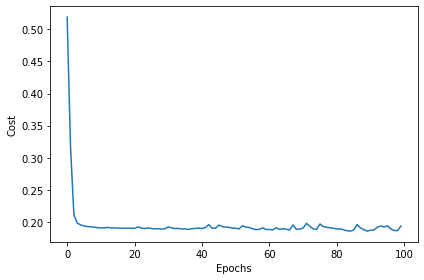

```
Wall time: 50.8 s
```

```python
%%time
params = dict(n_hidden=50,
              C = 0.01,
              epochs=100, # iterations
              eta=0.00001,  # learning rate
              random_state=1)

nn = TwoLayerPerceptron(**params)
nn.fit(trainX, trainY, print_progress=1)
yhat_1 = nn.predict(testX)

print('Test acc:',accuracy_score(testY,yhat_1))
plot_cost(nn.cost_)
```

```
<sklearn.metrics._plot.confusion_matrix.ConfusionMatrixDisplay at 0x216adfd1148>
```

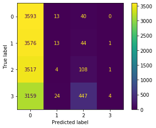

```python
from sklearn import metrics as mt
from sklearn.metrics import confusion_matrix, ConfusionMatrixDisplay

classes = [0,1,2,3]
cm = mt.confusion_matrix(testY, yhat_1, labels=classes)
disp = ConfusionMatrixDisplay(confusion_matrix=cm, display_labels=classes)
disp.plot()
```

```python
print(mt.confusion_matrix(testY,yhat_1))
print(mt.classification_report(testY,yhat_1))
```

```
[[3593   13   40    0]
 [3576   13   44    1]
 [3517    4  108    1]
 [3159   24  447    4]]
              precision    recall  f1-score   support

           0       0.26      0.99      0.41      3646
           1       0.24      0.00      0.01      3634
           2       0.17      0.03      0.05      3630
           3       0.67      0.00      0.00      3634

    accuracy                           0.26     14544
   macro avg       0.33      0.25      0.12     14544
weighted avg       0.33      0.26      0.12     14544
```

## Mini Batch

```python
# Example adapted from https://github.com/rasbt/python-machine-learning-book/blob/master/code/ch12/ch12.ipynb
# Original Author: Sebastian Raschka
# This is the optional book we use in the course, excellent intuitions and straightforward programming examples
# please note, however, that this code has been manipulated to reflect our assumptions and notation.
class TLPVectorizedMiniBatch(TwoLayerPerceptron):
    def __init__(self, alpha=0.1, decrease_const=0.0, shuffle=True, minibatches=1, **kwds):
        # need to add to the original initializer
        self.alpha = alpha
        self.decrease_const = decrease_const
        self.shuffle = shuffle
        self.minibatches = minibatches
        # but keep other keywords
        super().__init__(**kwds)

    def fit(self, X, y, print_progress=0):
        """ Learn weights from training data."""
        X_data, y_data = X.copy(), y.copy()
        Y_enc = self._encode_labels(y)

        # init weights and setup matrices
        self.n_features_ = X_data.shape[1]
        self.n_output_ = Y_enc.shape[0]
        self.W1, self.W2 = self._initialize_weights()

        # start momentum at zero for previous updates
        rho_W1_prev = np.zeros(self.W1.shape) # for momentum
        rho_W2_prev = np.zeros(self.W2.shape) # for momentum

        self.cost_ = []
        for i in range(self.epochs):

            # adaptive learning rate
            eta = self.eta / (1 + self.decrease_const*i) # decreasing learning rate
            # there are many forms of adaptive learning rates out there!

            if print_progress>0 and (i+1)%print_progress==0:
                sys.stderr.write('\rEpoch: %d/%d' % (i+1, self.epochs))
                sys.stderr.flush()

            if self.shuffle:
                ridx = np.random.permutation(y_data.shape[0])
                X_data, Y_enc = X_data[ridx], Y_enc[:, ridx]

            # use numpy split to split into equal sized batches
            # num batches== self.minibatches
            mini = np.array_split(range(y_data.shape[0]), self.minibatches)
            mini_cost = []
            for idx in mini:

                # feedforward
                A1, Z1, A2, Z2, A3 = self._feedforward(X_data[idx],
                                                       self.W1,
                                                       self.W2)

                cost = self._cost(A3,Y_enc[:, idx],self.W1,self.W2)
                mini_cost.append(cost) # this appends cost of mini-batch only

                # compute gradient via backpropagation
                grad1, grad2 = self._get_gradient(A1=A1, A2=A2, A3=A3, Z1=Z1, Z2=Z2,
                                                  Y_enc=Y_enc[:, idx],
                                                  W1=self.W1, W2=self.W2)

                rho_W1, rho_W2 = eta * grad1, eta * grad2
                self.W1 -= (rho_W1 + (self.alpha * rho_W1_prev)) # update with momentum
                self.W2 -= (rho_W2 + (self.alpha * rho_W2_prev)) # update with momentum
                rho_W1_prev, rho_W2_prev = rho_W1, rho_W2

            self.cost_.append(mini_cost)

        return self
```

```python
%%time
params = dict(n_hidden=50,
              C = 0.01,
              epochs=100, # iterations
              eta=0.00001,  # learning rate
              random_state=1)
nn_mini = TLPVectorizedMiniBatch(**params,
                          alpha=0.1,# momentum calculation
                          decrease_const=0.1, # decreasing eta
                          minibatches=len(trainX.values)/32, # minibatch size
                          shuffle=True)


nn_mini.fit(trainX.values, trainY, print_progress=1)
yhat_2 = nn_mini.predict(testX.values)
print('Accuracy:',accuracy_score(testY,yhat_2))
```

```
Epoch: 100/100
```

```
Accuracy: 0.35512926292629265
Wall time: 1min 29s
```

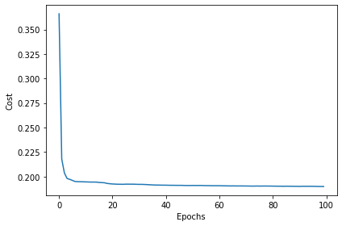

```python
plot_cost(nn_mini.cost_)
```

```
<sklearn.metrics._plot.confusion_matrix.ConfusionMatrixDisplay at 0x216ad0e0a48>
```

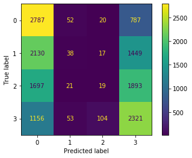

```python
cm = mt.confusion_matrix(testY, yhat_2, labels=classes)
disp = ConfusionMatrixDisplay(confusion_matrix=cm, display_labels=classes)
disp.plot()
```

```python
print(mt.confusion_matrix(testY,yhat_2))
print(mt.classification_report(testY,yhat_2))
```

```
[[2787   52   20  787]
 [2130   38   17 1449]
 [1697   21   19 1893]
 [1156   53  104 2321]]
              precision    recall  f1-score   support

           0       0.36      0.76      0.49      3646
           1       0.23      0.01      0.02      3634
           2       0.12      0.01      0.01      3630
           3       0.36      0.64      0.46      3634

    accuracy                           0.36     14544
   macro avg       0.27      0.35      0.24     14544
weighted avg       0.27      0.36      0.24     14544
```

In looking at the mini batch two layer perceptron without data normalization and without one-hot encoding any of the data above, we can see that the model does not do the best job of predicting the data. The maximum precision score is only 0.36 for both classes 0 and 3. Additionally, the minimum recall score is 0.01 for both classes 1 and 2. This indicates that this model is not doing a great job in limiting the number of false positives (precision) and false negatives (recall).

## Using Normalized Continuous Feature Data

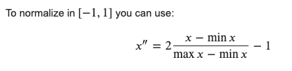

Source for normalization: https://stats.stackexchange.com/questions/178626/how-to-normalize-data-between-1-and-1

```python
# normalizing continuous numeric feature data
from sklearn import preprocessing

trainNormX = (2 * ((trainX - trainX.min())/(trainX.max() - trainX.min()))) - 1
testNormX = (2 * ((testX - testX.min())/(testX.max() - testX.min()))) - 1
```

```
Epoch: 100/100
```

```
Test acc: 0.5068069306930693
```

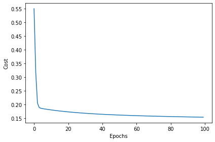

```
Wall time: 29.8 s
```

```python
%%time
params = dict(n_hidden=50,
              C = 0.01,
              epochs=100, # iterations
              eta=0.00001,  # learning rate
              random_state=1)

nn = TwoLayerPerceptron(**params)
nn.fit(trainNormX, trainY, print_progress=1)
yhat_3 = nn.predict(testNormX)

print('Test acc:',accuracy_score(testY,yhat_3))
plot_cost(nn.cost_)
```

```
<sklearn.metrics._plot.confusion_matrix.ConfusionMatrixDisplay at 0x216ae1fa508>
```

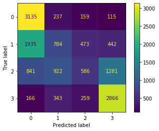

```python
cm2 = mt.confusion_matrix(testY, yhat_3, labels=classes)
disp2 = ConfusionMatrixDisplay(confusion_matrix=cm2, display_labels=classes)
disp2.plot()
```

```python
print(mt.confusion_matrix(testY,yhat_3))
print(mt.classification_report(testY,yhat_3))
```

```
[[3135  237  159  115]
 [1935  784  473  442]
 [ 841  922  586 1281]
 [ 166  343  259 2866]]
              precision    recall  f1-score   support

           0       0.52      0.86      0.64      3646
           1       0.34      0.22      0.26      3634
           2       0.40      0.16      0.23      3630
           3       0.61      0.79      0.69      3634

    accuracy                           0.51     14544
   macro avg       0.47      0.51      0.46     14544
weighted avg       0.47      0.51      0.46     14544
```

This time, the model included normalized continuous feature data. This produced a much better result than before as it is now predicting all 4 classes as seen evident in both the confusion matrix and classification report. However, the model still doesn't seem to be very great despite being better than the previous model. For example, this model does a very poor job with both class 1 and class 2. Class 1 has a precision of 0.34 and a recall of 0.22. For class 1, it looks like the model tends to predict class 0 the most (it predicts class 0 two times more often than correctly predicting class 1). When the true label is class 2, the model does a very poor job in predicting the label as seen with its precision score of 0.4 and a recall of 0.16. This problem of predicting class 2 can be seen evident with the model predicting class classes 0, 1, and 3 more often than class 2 even when it is class 2.

## Using Normalized Continuous Feature Data - With Mini Batching

```python
%%time
params = dict(n_hidden=50,
              C = 0.01,
              epochs=100, # iterations
              eta=0.00001,  # learning rate
              random_state=1)
nn_mini = TLPVectorizedMiniBatch(**params,
                          alpha=0.1,# momentum calculation
                          decrease_const=0.1, # decreasing eta
                          minibatches=len(trainX.values)/32, # minibatch size
                          shuffle=True)


nn_mini.fit(trainNormX.values, trainY, print_progress=1)
yhat_4 = nn_mini.predict(testNormX.values)
print('Accuracy:',accuracy_score(testY,yhat_4))
```

```
Epoch: 100/100
```

```
Accuracy: 0.4730473047304731
Wall time: 1min 24s
```

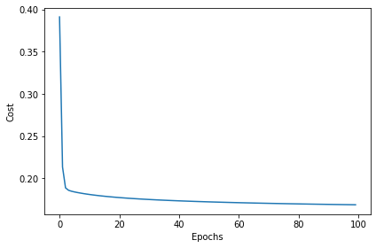

```python
plot_cost(nn_mini.cost_)
```

```
<sklearn.metrics._plot.confusion_matrix.ConfusionMatrixDisplay at 0x216aca29748>
```

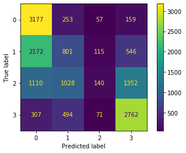

```python
cm2 = mt.confusion_matrix(testY, yhat_4, labels=classes)
disp2 = ConfusionMatrixDisplay(confusion_matrix=cm2, display_labels=classes)
disp2.plot()
```

```python
print(mt.confusion_matrix(testY,yhat_4))
print(mt.classification_report(testY,yhat_4))
```

```
[[3177  253   57  159]
 [2172  801  115  546]
 [1110 1028  140 1352]
 [ 307  494   71 2762]]
              precision    recall  f1-score   support

           0       0.47      0.87      0.61      3646
           1       0.31      0.22      0.26      3634
           2       0.37      0.04      0.07      3630
           3       0.57      0.76      0.65      3634

    accuracy                           0.47     14544
   macro avg       0.43      0.47      0.40     14544
weighted avg       0.43      0.47      0.40     14544
```

Similar to above, the mini batch model with normalization is a step in the right direction but still off from being optimal.

## Normalized and One-Hot Encoded

```python
# the dataframe from the last TLP is normalized data
# now we will convert state and county to one hot encoded features

trainOHE = trainNormX.drop(['State'], axis=1)
OHE_state = pd.get_dummies(trainNormX['State'], prefix='State')
frames = [trainOHE, OHE_state]
XtrainOHE = pd.concat(frames, axis=1)

testOHE = testNormX.drop(['State'], axis=1)
OHE_state = pd.get_dummies(testNormX['State'], prefix='State')
frames = [testOHE, OHE_state]
XtestOHE = pd.concat(frames, axis=1)
```

```
Epoch: 100/100
```

```
Test acc: 0.4860423542354235
```

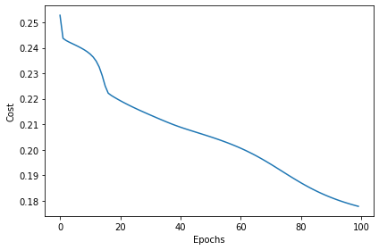

```
Wall time: 42.5 s
```

```python
%%time
params = dict(n_hidden=50,
              C = 0.01,
              epochs=100, # iterations
              eta=0.00001,  # learning rate
              random_state=1)

nn = TwoLayerPerceptron(**params)
nn.fit(XtrainOHE, trainY, print_progress=1)
yhat_5 = nn.predict(XtestOHE)

print('Test acc:',accuracy_score(testY,yhat_5))
plot_cost(nn.cost_)
```

```
<sklearn.metrics._plot.confusion_matrix.ConfusionMatrixDisplay at 0x216ad2a4048>
```

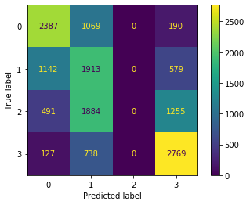

```python
cm = mt.confusion_matrix(testY, yhat_5, labels=classes)
disp = ConfusionMatrixDisplay(confusion_matrix=cm, display_labels=classes)
disp.plot()
```

```python
print(mt.confusion_matrix(testY,yhat_5))
print(mt.classification_report(testY,yhat_5))
```

```
[[2387 1069    0  190]
 [1142 1913    0  579]
 [ 491 1884    0 1255]
 [ 127  738    0 2769]]
              precision    recall  f1-score   support

           0       0.58      0.65      0.61      3646
           1       0.34      0.53      0.41      3634
           2       0.00      0.00      0.00      3630
           3       0.58      0.76      0.66      3634

    accuracy                           0.49     14544
   macro avg       0.37      0.49      0.42     14544
weighted avg       0.37      0.49      0.42     14544
```

## Normalized and One-Hot Encoded - With Mini Batching

```python
%%time
nn_mini = TLPVectorizedMiniBatch(**params,
                          alpha=0.1,# momentum calculation
                          decrease_const=0.1, # decreasing eta
                          minibatches=len(trainX.values)/32, # minibatch size
                          shuffle=True)


nn_mini.fit(XtrainOHE.values, trainY, print_progress=1)
yhat_6 = nn_mini.predict(XtestOHE.values)
print('Accuracy:',accuracy_score(testY,yhat_6))
```

```
Epoch: 100/100
```

```
Accuracy: 0.3065181518151815
Wall time: 1min 20s
```

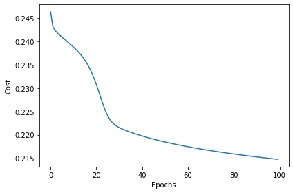

```python
plot_cost(nn_mini.cost_)
```

```
<sklearn.metrics._plot.confusion_matrix.ConfusionMatrixDisplay at 0x216ae094348>
```

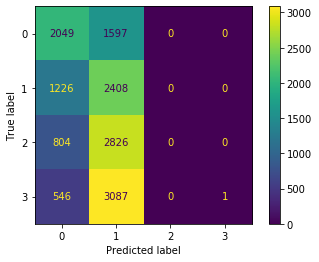

```python
cm = mt.confusion_matrix(testY, yhat_6, labels=classes)
disp = ConfusionMatrixDisplay(confusion_matrix=cm, display_labels=classes)
disp.plot()
```

```python
print(mt.confusion_matrix(testY,yhat_6))
print(mt.classification_report(testY,yhat_6))
```

```
[[2049 1597    0    0]
 [1226 2408    0    0]
 [ 804 2826    0    0]
 [ 546 3087    0    1]]
              precision    recall  f1-score   support

           0       0.44      0.56      0.50      3646
           1       0.24      0.66      0.36      3634
           2       0.00      0.00      0.00      3630
           3       1.00      0.00      0.00      3634

    accuracy                           0.31     14544
   macro avg       0.42      0.31      0.21     14544
weighted avg       0.42      0.31      0.21     14544
```

Adding in the OHE for both the regular two layer perceptron and the mini-batching resulted in the model's performance going down as seen with the drop in accuracy for both of them relative to their counter-part with just normalization. Also, the mini batch model does not predict class 2 at all and only predicts class 3 once. This drop in performance and lack of predicting all the classes is due to one hot encoding too many attributes.

## Comparing the models

To compare our models we will run chi-squared tests. Our null hypothesis will be that the models are similar and we can reject this hypothesis if our chi squared statistic shows greater than 95% confidence.

```python
def chiSq(b,c):
    chi_square = (abs(b-c)-1)**2/(b+c)
    return chi_square > 3.841
```

```python
yhat1_acc = yhat_1 == testY # No mini, no normal and no OHE
yhat2_acc = yhat_2 == testY # Mini, no normal and no OHE
yhat3_acc = yhat_3 == testY # No mini, normal, no OHE
yhat4_acc = yhat_4 == testY # Mini, normal, no OHE
yhat5_acc = yhat_5 == testY # No Mini, normal, OHE
yhat6_acc = yhat_6 == testY # Mini, normal, OHE

#Just going to test whether the mini batch models differ or not
acc_list = [yhat2_acc,yhat4_acc,yhat6_acc]
pairs_to_compare = [[0,1],[1,2],[0,2]]

for x,y in pairs_to_compare:
    b = 0
    c = 0

    for i, v in enumerate(testY):
        if acc_list[x][i] and not acc_list[y][i]:
            b += 1
        elif not acc_list[x][i] and acc_list[y][i]:
            c += 1
    if chiSq(b,c):
        print('We can assume models',x, 'and', y,'are different as indicated by the chi-squared test')
    else:
        print('We cannot assume that',x, 'and', y,'are different models as indicated by the chi-squared test')
```

```
We can assume models 0 and 1 are different as indicated by the chi-squared test
We can assume models 1 and 2 are different as indicated by the chi-squared test
We can assume models 0 and 2 are different as indicated by the chi-squared test
```

As indicated by the confusion matrices and the chi squared tests we can see that the models are different in their predictions and scores. This demonstartes the impact that both normalization and one hot encoding has on a model.

## Multi-Layer Perceptron

```python
class MultiLayerPerceptronBase(object):
    def __init__(self, n_layers = 3, n_hidden=30,
                 C=0.0, epochs=500, eta=0.001, random_state=None, alpha=0):
        np.random.seed(random_state)
        self.n_layers = n_layers
        self.n_hidden = n_hidden
        self.l2_C = C
        self.epochs = epochs
        self.eta = eta
        self.gradientMags = []
        self.alpha = alpha

    @staticmethod
    def _encode_labels(y):
        """Encode labels into one-hot representation"""
        onehot = pd.get_dummies(y).values.T

        return onehot

    def _initialize_weights(self):

        Ws = []
        rows = self.n_hidden
        cols = self.n_features_

        for layer in range(self.n_layers - 1):
            # glorot initialization
            init_bound = 4*np.sqrt(6. / (rows + cols + 1))
            W1 = np.random.uniform(-init_bound, init_bound,(rows, cols+1))
            W1[:,:1] = 0
            Ws.append(W1)
            cols = rows

        init_bound = 4*np.sqrt(6 / (self.n_output_ + self.n_hidden + 1))
        W2 = np.random.uniform(-init_bound, init_bound,(self.n_output_, self.n_hidden + 1))
        W2[:,:1] = 0
        Ws.append(W2)
        return Ws

    @staticmethod
    def _sigmoid(z):
        return expit(z)

    @staticmethod
    def _add_bias_unit(X, how='column'):
        """Add bias unit (column or row of 1s) to array at index 0"""
        if how == 'column':
            ones = np.ones((X.shape[0], 1))
            X_new = np.hstack((ones, X))
        elif how == 'row':
            ones = np.ones((1, X.shape[1]))
            X_new = np.vstack((ones, X))
        return X_new

    @staticmethod
    def _L2_reg(lambda_, W):
        """Compute L2-regularization cost"""
        # only compute for non-bias terms
        meansum = 0
        for w in W:
            meansum += np.mean(w[:, 1:] ** 2)
        return (lambda_/2.0) * np.sqrt(meansum)

    def _cost(self,A3,Y_enc,W):
        '''Get the objective function value'''
        cost = np.mean((Y_enc-A3)**2)
        L2_term = self._L2_reg(self.l2_C, W)
        return cost + L2_term

    def getAvgMags(self):
        return self.gradientMags

    def plotMagnitudes(self):
        fig, axes = plt.subplots(1, self.n_layers, figsize=(15, 5))
        axes[0].set_ylabel('Gradient Magnitude')
        fig.suptitle('Gradient Magnitude by Layer')
        for i in range(self.n_layers):
            mags = np.array(self.gradientMags)
            axes[i].plot(range(self.epochs), mags[:, i])
            axes[i].set_xlabel('Epochs'.format(i))
        plt.show()




class MultiLayerPerceptron(MultiLayerPerceptronBase):

    def _feedforward(self, X, W):
        """Compute feedforward step
        -----------
        X : Input layer with original features.
        W1: Weight matrix for input layer -> hidden layer.
        W2: Weight matrix for hidden layer -> output layer.
        ----------
        a1-a3 : activations into layer (or output layer)
        z1-z2 : layer inputs

        """
        AVals = []
        ZVals = []
        A = self._add_bias_unit(X.T, how='row')
        AVals.append(A)

        for i, layer in enumerate(W):
            Z1 = (layer @ A)
            ZVals.append(Z1)

            A = self._sigmoid(Z1)
            if i != len(W)-1:
                A = self._add_bias_unit(A, how='row')
            AVals.append(A)
        return AVals, ZVals

    def _get_gradient(self, As, Zs, Y_enc, Ws):
        """ Compute gradient step using backpropagation.
        """
        # vectorized backpropagation
        V = []
        grad = []
        V.append(-2*(Y_enc-As[-1])*As[-1]*(1-As[-1]))

        for i in range(len(As)-2,0,-1):
            if i != self.n_layers - 1:
                # need to take off the bias
                V2 = (As[i]*(1-As[i]))*(Ws[i].T @ V[0][1:,:])
            else:
                V2 = As[i]*(1-As[i])*(Ws[i].T @ V[0])
            V.insert(0, V2)

        vToEnd = len(V) - 1

        for i, v in enumerate(V) :
            if i != vToEnd :
                g = v[1:,:] @ As[i].T
                grad.append(g)


        grad.append(V[vToEnd] @ As[vToEnd].T)

        layerMags = []
        for i, w in enumerate(Ws) :
            grad[i][:, 1:] += w[:, 1:] * self.l2_C
            magAtLayer = np.mean(abs(grad[i]))
            layerMags.append(magAtLayer)


        self.gradientMags.append(layerMags)

        return grad

    def predict(self, X):
        """Predict class labels"""
        As, _ = self._feedforward(X, self.Ws)
        y_pred = np.argmax(As[-1], axis=0)
        return y_pred


    def fit(self, X, y, print_progress=False):
        """ Learn weights from training data."""
        X_data, y_data = X.copy(), y.copy()
        Y_enc = self._encode_labels(y)
        # init weights and setup matrices
        self.n_features_ = X_data.shape[1]
        self.n_output_ = Y_enc.shape[0]
        self.Ws = self._initialize_weights()
        self.cost_ = []
        #rho_prevs = np.zeros(self.Ws.shape)
        rho_prevs = []
        for w in self.Ws :
            rho_prevs.append(w)
        rhos = []
        for i in range(self.epochs):
            if print_progress>0 and (i+1)%print_progress==0:
                sys.stderr.write('\rEpoch: %d/%d' % (i+1, self.epochs))
                sys.stderr.flush()
            # feedforward all instances
            As, Zs = self._feedforward(X_data,self.Ws)
            cost = self._cost(As[-1],Y_enc,self.Ws)
            self.cost_.append(cost)
            # compute gradient via backpropagation
            grad = self._get_gradient(As=As, Zs=Zs, Y_enc=Y_enc,
                                              Ws=self.Ws)
            """
                rho_W1, rho_W2 = eta * grad1, eta * grad2
                self.W1 -= (rho_W1 + (self.alpha * rho_W1_prev))
                self.W2 -= (rho_W2 + (self.alpha * rho_W2_prev))
                rho_W1_prev, rho_W2_prev = rho_W1, rho_W2
            """
            if self.alpha != 0 :
                for i in range(len(self.Ws) ) :
                    rhos.append(self.eta * grad[i])
                    rhos[i] = self.eta * grad[i]
                    self.Ws[i] -= (rhos[i] + (self.alpha * rho_prevs[i]))
                    rho_prevs[i] = rhos[i]
            for i, w in enumerate(self.Ws) :
                self.Ws[i] -= self.eta * grad[i]
        return self
```

```
Epoch: 50/50
```

```
Test acc: 0.5019939493949395
```

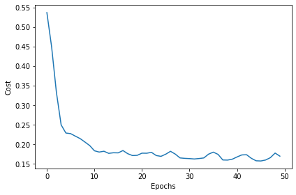

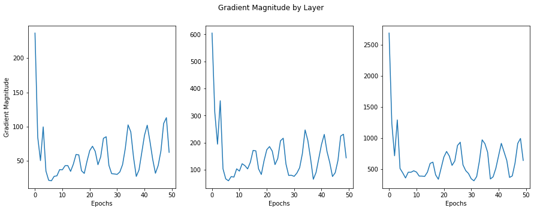

```python
params = dict(n_hidden=40,
              epochs=50, # iterations
              eta=0.00001,  # learning rate
              alpha=0.1,
              random_state=1,
              n_layers=3)

nn = MultiLayerPerceptron(**params)
nn.fit(XtrainOHE, trainY, print_progress=1)
yhat_7 = nn.predict(XtestOHE)

print('Test acc:',accuracy_score(testY,yhat_7))
plot_cost(nn.cost_)

nn.plotMagnitudes()
```

```python
print(mt.confusion_matrix(testY,yhat_7))
print(mt.classification_report(testY,yhat_7))
```

```
[[2988   38  550   70]
 [1860   52 1401  321]
 [ 812   40 1761 1017]
 [ 176    7  951 2500]]
              precision    recall  f1-score   support

           0       0.51      0.82      0.63      3646
           1       0.38      0.01      0.03      3634
           2       0.38      0.49      0.42      3630
           3       0.64      0.69      0.66      3634

    accuracy                           0.50     14544
   macro avg       0.48      0.50      0.44     14544
weighted avg       0.48      0.50      0.44     14544
```

```
Epoch: 50/50
```

```
Test acc: 0.4940181518151815
```

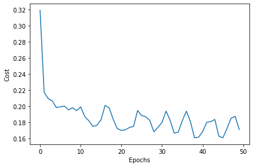

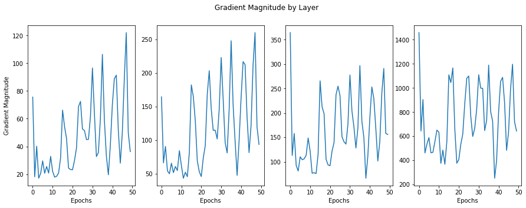

```python
params = dict(n_hidden=40,
              epochs=50, # iterations
              eta=0.00001,  # learning rate
              alpha=0.1,
              random_state=1,
              n_layers=4)

nn = MultiLayerPerceptron(**params)
nn.fit(XtrainOHE, trainY, print_progress=1)
yhat_8 = nn.predict(XtestOHE)

print('Test acc:',accuracy_score(testY,yhat_8))
plot_cost(nn.cost_)

nn.plotMagnitudes()
```

```python
print(mt.confusion_matrix(testY,yhat_8))
print(mt.classification_report(testY,yhat_8))
```

```
[[2352  717  400  177]
 [1311  772  994  557]
 [ 534  448 1307 1341]
 [ 122  103  655 2754]]
              precision    recall  f1-score   support

           0       0.54      0.65      0.59      3646
           1       0.38      0.21      0.27      3634
           2       0.39      0.36      0.37      3630
           3       0.57      0.76      0.65      3634

    accuracy                           0.49     14544
   macro avg       0.47      0.49      0.47     14544
weighted avg       0.47      0.49      0.47     14544
```

```
Epoch: 100/100
```

```
Test acc: 0.47875412541254125
```

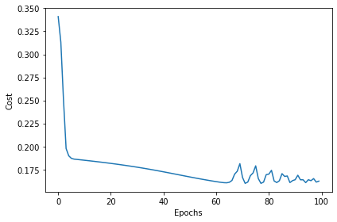

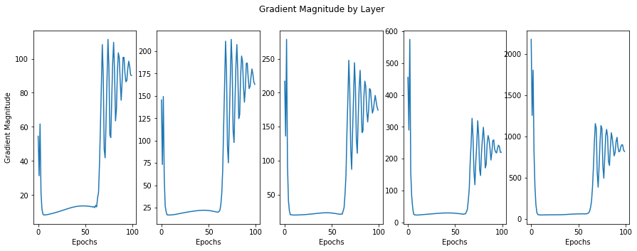

```python
params = dict(n_hidden=40,
              epochs=100, # iterations
              eta=0.00001,  # learning rate
              alpha=0,
              random_state=1,
              n_layers=5)

nn = MultiLayerPerceptron(**params)
nn.fit(XtrainOHE, trainY, print_progress=1)
yhat_9 = nn.predict(XtestOHE)

print('Test acc:',accuracy_score(testY,yhat_9))
plot_cost(nn.cost_)

nn.plotMagnitudes()
```

```
Epoch: 100/100
```

```
Test acc: 0.49573707370737075
```

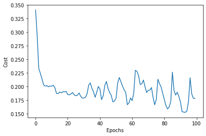

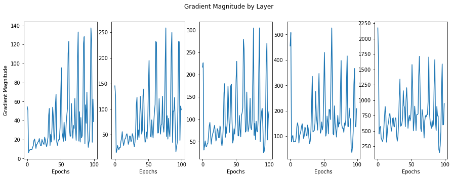

```python
params = dict(n_hidden=40,
              epochs=100, # iterations
              eta=0.00001,  # learning rate
              alpha=0.1,
              random_state=1,
              n_layers=5)

nn = MultiLayerPerceptron(**params)
nn.fit(XtrainOHE, trainY, print_progress=1)
yhat_10 = nn.predict(XtestOHE)

print('Test acc:',accuracy_score(testY,yhat_10))
plot_cost(nn.cost_)

nn.plotMagnitudes()
```

```python
print(mt.confusion_matrix(testY,yhat_9))
print(mt.classification_report(testY,yhat_9))
```

```
[[1751  795  853  247]
 [ 644  720 1513  757]
 [ 189  301 1407 1733]
 [  34   40  475 3085]]
              precision    recall  f1-score   support

           0       0.67      0.48      0.56      3646
           1       0.39      0.20      0.26      3634
           2       0.33      0.39      0.36      3630
           3       0.53      0.85      0.65      3634

    accuracy                           0.48     14544
   macro avg       0.48      0.48      0.46     14544
weighted avg       0.48      0.48      0.46     14544
```

```python
print(mt.confusion_matrix(testY,yhat_10))
print(mt.classification_report(testY,yhat_10))
```

```
[[2585    0  857  204]
 [1295    0 1698  641]
 [ 445    0 1584 1601]
 [  72    0  521 3041]]
              precision    recall  f1-score   support

           0       0.59      0.71      0.64      3646
           1       0.00      0.00      0.00      3634
           2       0.34      0.44      0.38      3630
           3       0.55      0.84      0.67      3634

    accuracy                           0.50     14544
   macro avg       0.37      0.50      0.42     14544
weighted avg       0.37      0.50      0.42     14544
```

We compared a 5 layer neural network using momentum vs not using momentum. The model that used momentum performed better with its accuracy improving despite not predicting class 1 at all. The ability to limit the number of false negatives improves a lot with the momentum model (besides for class 1) as seen with the recall score imporving in all of the classes or remaining nearly constant (just a 0.01 drop in class 3's recall score).

# Exceptional Work: AdaM

```python
class AdaM(MultiLayerPerceptron):
    def __init__(self, beta_1=0.9, beta_2 = 0.999, **kwds):
        # need to add to the original initializer
        self.beta_1 = beta_1
        self.beta_2 = beta_2
        # but keep other keywords
        super().__init__(**kwds)

    def fit(self, X, y, print_progress=False):
        """ Learn weights from training data."""
        X_data, y_data = X.copy(), y.copy()
        Y_enc = self._encode_labels(y)
        # init weights and setup matrices
        self.n_features_ = X_data.shape[1]
        self.n_output_ = Y_enc.shape[0]
        self.Ws = self._initialize_weights()
        self.cost_ = []

        mK = []
        vK = []
        mK_hat = []
        vK_hat = []
        epsilon = 10**-8

        for j in range(len(self.Ws)):
            mK.append(np.zeros(self.Ws[j].shape))
            vK.append(np.zeros(self.Ws[j].shape))
            mK_hat.append(np.zeros(self.Ws[j].shape))
            vK_hat.append(np.zeros(self.Ws[j].shape))

        for i in range(self.epochs):
            if print_progress>0 and (i+1)%print_progress==0:
                sys.stderr.write('\rEpoch: %d/%d' % (i+1, self.epochs))
                sys.stderr.flush()
            # feedforward all instances
            As, Zs = self._feedforward(X_data,self.Ws)
            cost = self._cost(As[-1],Y_enc,self.Ws)
            self.cost_.append(cost)
            # compute gradient via backpropagation
            grad = self._get_gradient(As=As, Zs=Zs, Y_enc=Y_enc,
                                              Ws=self.Ws)

            #AdaM operations for each epoch
            for j in range(len(self.Ws) ) :

                mK[j] = self.beta_1 * mK[j] + (1 - self.beta_1) * grad[j]
                vK[j] = self.beta_2 * vK[j] + (1 - self.beta_2) * (grad[j]**2)

                mK_hat[j] = mK[j] / (1 - self.beta_1)
                vK_hat[j] = vK[j] / (1 - self.beta_2)

                self.Ws[j] = self.Ws[j] - self.eta * (mK_hat[j] / np.sqrt(vK_hat[j]+epsilon))

        return self
```

```
Epoch: 50/50
```

```
Test acc: 0.5754262926292629
```

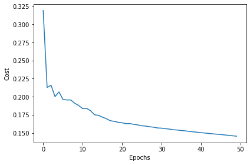

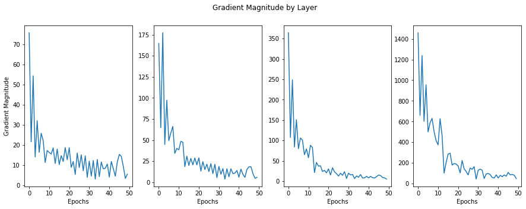

```python
params = dict(n_hidden=40,
              epochs=50, # iterations
              eta=0.02,  # learning rate
              random_state=1,
              n_layers=4)

nn = AdaM(**params)
nn.fit(XtrainOHE, trainY, print_progress=1)
yhat_11 = nn.predict(XtestOHE)

print('Test acc:',accuracy_score(testY,yhat_11))
plot_cost(nn.cost_)

nn.plotMagnitudes()
```

```
Epoch: 100/100
```

```
Test acc: 0.6586221122112211
```

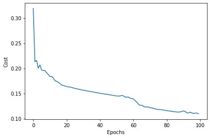

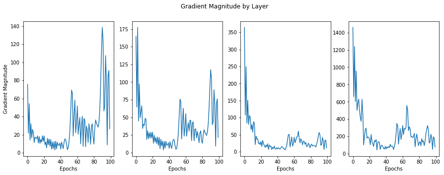

```python
params = dict(n_hidden=40,
              epochs=100, # iterations
              eta=0.02,  # learning rate
              random_state=1,
              n_layers=4)

nn = AdaM(**params)
nn.fit(XtrainOHE, trainY, print_progress=1)
yhat_12 = nn.predict(XtestOHE)

print('Test acc:',accuracy_score(testY,yhat_12))
plot_cost(nn.cost_)

nn.plotMagnitudes()
```

```
Epoch: 200/200
```

```
Test acc: 0.7090896589658966
```

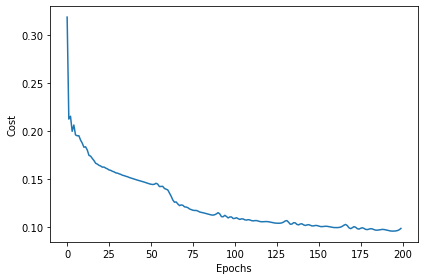

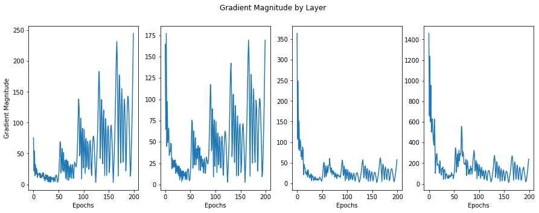

```python
params = dict(n_hidden=40,
              epochs=200, # iterations
              eta=0.02,  # learning rate
              random_state=1,
              n_layers=4)

nn = AdaM(**params)
nn.fit(XtrainOHE, trainY, print_progress=1)
yhat_13 = nn.predict(XtestOHE)

print('Test acc:',accuracy_score(testY,yhat_13))
plot_cost(nn.cost_)

nn.plotMagnitudes()
```

```python
print(mt.confusion_matrix(testY,yhat_11))
print(mt.classification_report(testY,yhat_11))
```

```
[[3148    0  463   35]
 [1973    0 1577   84]
 [ 561    0 2468  601]
 [  46    0  835 2753]]
              precision    recall  f1-score   support

           0       0.55      0.86      0.67      3646
           1       0.00      0.00      0.00      3634
           2       0.46      0.68      0.55      3630
           3       0.79      0.76      0.77      3634

    accuracy                           0.58     14544
   macro avg       0.45      0.58      0.50     14544
weighted avg       0.45      0.58      0.50     14544
```

```python
print(mt.confusion_matrix(testY,yhat_12))
print(mt.classification_report(testY,yhat_12))
```

```
[[2857  627  120   42]
 [1169 1801  610   54]
 [ 152  947 2119  412]
 [   6   46  780 2802]]
              precision    recall  f1-score   support

           0       0.68      0.78      0.73      3646
           1       0.53      0.50      0.51      3634
           2       0.58      0.58      0.58      3630
           3       0.85      0.77      0.81      3634

    accuracy                           0.66     14544
   macro avg       0.66      0.66      0.66     14544
weighted avg       0.66      0.66      0.66     14544
```

```python
print(mt.confusion_matrix(testY,yhat_13))
print(mt.classification_report(testY,yhat_13))
```

```
[[2792  684  115   55]
 [ 753 2168  651   62]
 [  38  725 2414  453]
 [   1   22  672 2939]]
              precision    recall  f1-score   support

           0       0.78      0.77      0.77      3646
           1       0.60      0.60      0.60      3634
           2       0.63      0.67      0.65      3630
           3       0.84      0.81      0.82      3634

    accuracy                           0.71     14544
   macro avg       0.71      0.71      0.71     14544
weighted avg       0.71      0.71      0.71     14544
```

Adam clearly performed better than the previous models. For the Adam model, it also shows that increasing the number of epochs has a large influence on the model and its accuracy as seen with the plots comparing the cost vs epochs in addition to just loooking at the sheer improvement in accuracy for 50 epochs (57.5%) vs 200 epochs (70.9%).